# BIDV Framework Recommendation Report

Portfolio Alignment & Transition Stress Testing for Decision 263 Sectors

May 23, 2026 | Prepared by GTB Advisory | Illustrative analysis (synthetic MCB portfolio)

CONFIDENTIAL — FOR AUTHORIZED RECIPIENTS ONLY

## Executive Summary

This report evaluates leading portfolio alignment and climate risk frameworks against BIDV's specific context and regulatory obligations under **Decision 263** (Quyết định 263/QĐ-TTg), which mandates GHG emission inventories and sector-specific quotas for thermal power, steel, and cement facilities. The analysis recommends a **PACTA + TRISK** analytical stack as the primary framework, supported by PCAF for emissions accounting and TCFD/ISSB S2 for disclosure.

POWER

Highest-Priority Sector

PACTA + TRISK

Recommended Framework

**Key Finding:** In the illustrative MCB synthetic portfolio, the **power sector dominates all three priority dimensions** (alignment gap, transition stress, and portfolio exposure), scoring maximum (1.0) on the composite priority scale. BIDV should prioritize power sector engagement, followed by steel and cement.

**What's next:** This report provides the framework evaluation, regulatory mapping, sector prioritization, and implementation roadmap. BIDV-specific results will be produced upon data onboarding through the BYOL (Bring Your Own Loanbook) intake process.

## BIDV Context

**Synthetic Data Notice:** Illustrative results based on synthetic portfolio (MCB). BIDV-specific results will be produced upon data onboarding.

### Decision 263 Obligations

Decision 263 (Quyết định 263/QĐ-TTg, 2022) mandates GHG emission inventories, sector-specific emission quotas, and emission reduction plans for facilities in **thermal power**, **steel**, and **cement**. Regulated entities must report emissions data starting from the 2025 reporting year. Commercial banks like BIDV should monitor borrower compliance as part of their ESG governance framework, since non-compliant borrowers face regulatory risk that translates to credit risk.

### PCAF Baseline Status

BIDV's financed emissions baseline (Output 2.1) is PCAF-based. The framework recommendation in this report positions PACTA/TRISK as the portfolio alignment and risk layer that sits on top of the PCAF emissions accounting foundation. Together, PCAF + PACTA + TRISK create a three-layer architecture: **measure** (emissions) → **compare** (alignment) → **act** (stress testing and engagement).

## Framework Landscape

Seven leading portfolio alignment and climate risk frameworks were evaluated across 10 dimensions relevant to BIDV's context: data input requirements, sector coverage (thermal power, steel, cement), Vietnam regulatory compatibility (Decision 263, SBV taxonomy), output types, implementation complexity, cost, open-source availability, time to first results, complementarity with PCAF baseline, and maturity/institutional adoption.

### 7 × 10 Scored Matrix

Each framework is scored: **Strong Fit** (addresses well for BIDV), **Partial Fit** (addresses with limitations), **Weak Fit** (does not meaningfully address).

| Dimension | PACTA | TRISK | PCAF | SBTi FI | GFANZ/NZBA | NGFS | IFRS S2 |
| --- | --- | --- | --- | --- | --- | --- | --- |
| --- | --- | --- | --- | --- | --- | --- | --- |
| **1. Data inputs** | Partial | Partial | Partial | Weak | Partial | Strong | Weak |
| **2. Sector coverage (power/steel/cement)** | Strong | Strong | Strong | Strong | Strong | Strong | Strong |
| **3. Vietnam regulatory compatibility** | Strong | Partial | Strong | Partial | Strong | Partial | Strong |
| **4. Output types** | Strong | Strong | Partial | Partial | Partial | Partial | Strong |
| **5. Implementation complexity** | Partial | Weak | Partial | Weak | Partial | Weak | Partial |
| **6. Cost** | Strong | Strong | Strong | Weak | Partial | Strong | Partial |
| **7. Open-source availability** | Strong | Strong | Strong | Partial | Strong | Partial | Partial |
| **8. Time to first results** | Strong | Partial | Strong | Weak | Partial | Weak | Weak |
| **9. Complementarity with PCAF** | Strong | Strong | — | Strong | Strong | Strong | Strong |
| **10. Maturity & ASEAN adoption** | Strong | Weak | Strong | Partial | Strong | Strong | Strong |

**Full analysis:** The complete framework comparison document (`docs/bidv_framework_comparison.md`) includes detailed scoring justifications for every cell, framework-by-framework evaluation narratives, and a complementarity analysis.

## Framework Recommendation

### Recommended Stack

Primary

**PACTA + TRISK**  
Portfolio alignment & transition stress testing

Secondary

**PCAF**  
Financed emissions accounting (prerequisite)

Tertiary

**TCFD / ISSB S2**  
Disclosure output framework

### Why This Stack

The recommended stack creates a **complete analytical pipeline** from measurement to action to disclosure:

| Layer | Framework | Question Answered |
| --- | --- | --- |
| 1. Measure | PCAF | "What are my financed emissions?" |
| 2. Align | PACTA | "Is my portfolio aligned with PDP8/NDC?" |
| 3. Stress | TRISK | "What is the financial impact?" |
| 4. Disclose | IFRS S2 | "How do I report to investors and regulators?" |

**PCAF** establishes the emissions baseline that all downstream analysis depends on. **PACTA** tells BIDV whether its portfolio is aligned with Vietnam's PDP8 and NDC targets — producing concrete gap percentages by sector and technology. **TRISK** translates PACTA's alignment gaps into borrower-level NPV and PD changes — giving credit risk teams the financial metrics they need to prioritize action. **IFRS S2** provides the disclosure framework that turns all upstream analytical outputs into investor-ready reporting.

### Complementary Frameworks

| Framework | Role | When to Consider |
| --- | --- | --- |
| GFANZ/NZBA | Governance wrapper & peer learning | When BIDV is ready for a public net-zero commitment |
| SBTi FI | Independent target validation | After PCAF accounting is mature and PACTA gaps are understood |
| NGFS | Scenario input provider | When more sophisticated macroeconomic scenarios are needed beyond PDP8/NDC |

## Sector Prioritization

**Synthetic Data Notice:** Illustrative results based on synthetic portfolio (MCB). BIDV-specific results will be produced upon data onboarding.

Sectors are ranked by a composite priority score combining three dimensions: **alignment gap** (weight: 0.35), **transition stress** (weight: 0.35), and **portfolio exposure** (weight: 0.30). Scores are min-max normalized across sectors to handle different units (percentage points vs. percent).

| Sector | Composite Score | Alignment | Stress Score | Exposure Share | Priority |
| --- | --- | --- | --- | --- | --- |
| **power** | 1.000 | 1.000 | 493.4 | 81.8% | Critical |
| **cement** | 0.011 | 0.000 | 100.0 | 10.4% | Low |
| **steel** | 0.158 | 0.453 | 100.0 | 7.8% | Low |

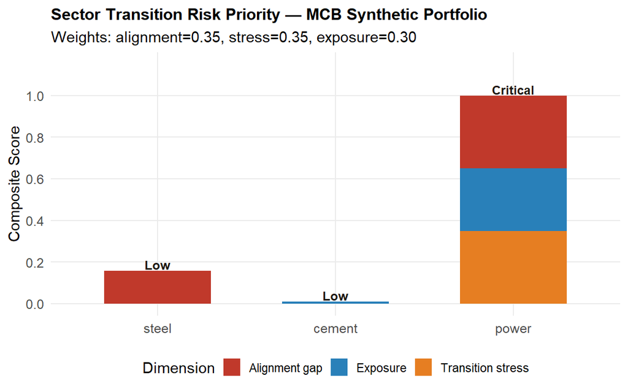

Figure: Sector priority ranking — composite scores across alignment, stress, and exposure dimensions.

# Sector Prioritization — Interpretation Notes (MCB Synthetic Portfolio)

> **Date:** 2026-05-22

> **Data source:** MCB synthetic portfolio (43 loans, ~19.3 billion VND Decision 263 exposure)

> **Weights:** alignment = 0.35, stress = 0.35, exposure = 0.30

## Ranking Results

| Rank | Sector | Composite Score | Priority Band | Key Driver |
| --- | --- | --- | --- | --- |
| 1 | **Power** | 1.000 | Critical | Dominates all three dimensions |
| 2 | **Steel** | 0.158 | Low | Moderate alignment gap (7.2%) |
| 3 | **Cement** | 0.011 | Low | Lowest alignment gap (2.1%) |

[output not shown]

## Interpretation

[output not shown]

[output not shown]

**Power is the unequivocal priority sector** for BIDV's climate risk management, scoring maximum (1.0) on the composite scale. This is driven by three converging factors:

[output not shown]

[output not shown]

1. **Alignment gap:** Power's coal capacity is 13.4 percentage points above the PDP8 target — the largest misalignment across all Decision 263 sectors. The portfolio is over-allocated to coal (37% vs. 24% target) and under-allocated to renewables (21% vs. 35% target).

[output not shown]

[output not shown]

**Transition stress:** The power sector has 13 borrowers with TRISK stress-test results, including three coal-heavy entities (Nghi Son Power LLC, Vinacomin Power JSC, International Power Mong Duong) with stress priority scores of 95–100. The exposure-weighted mean stress score is 493, far exceeding cement and steel (both 100, the floor value).

[output not shown]

[output not shown]

**Portfolio exposure:** Power accounts for 81.8% of total Decision 263-relevant exposure (15.8 billion VND of 19.3 billion VND). This concentration amplifies both the alignment and stress dimensions.

[output not shown]

[output not shown]

**Steel ranks second** (0.158) despite having only two borrowers because its SDA alignment gap (7.2% above 2030 target) is significantly higher than cement's (2.1%). However, steel's stress and exposure scores are both at or near zero, limiting its composite score.

[output not shown]

[output not shown]

**Cement ranks last** (0.011) with the smallest alignment gap (2.1%) and low exposure share (10.4%). The sector's two borrowers (VICEM, Holcim Group) show divergent stress scores (95 and 5), but the exposure-weighted mean is at the floor.

[output not shown]

[output not shown]

## Sensitivity Analysis

[output not shown]

[output not shown]

When weights shift toward alignment (0.50) and away from stress/exposure (0.25 each), steel's score increases from 0.158 to 0.226 — a 43% increase — reflecting its moderate alignment gap. The ranking order (power > steel > cement) is stable across all tested weight combinations, confirming that power's dominance is robust to reasonable weight variations.

[output not shown]

[output not shown]

## Caveats

[output not shown]

[output not shown]

- **Steel match coverage ~4%:** The MCB synthetic portfolio has very low steel match coverage, making steel alignment and stress results less reliable. Steel's true priority may be higher if additional borrowers were matched.

[output not shown]

- **Synthetic portfolio:** All results are based on the synthetic MCB portfolio, not real BIDV data. BIDV-specific results will differ based on actual sector exposure and borrower composition.

[output not shown]

- **Different alignment units:** Power gaps are in percentage points (market share) while cement/steel gaps are in percent (emission intensity). Min-max scaling makes them comparable by relative severity within the portfolio.

[output not shown]

[output not shown]

[output not shown]

[output not shown]

[output not shown]

## Decision 263 Compliance Mapping

**Regulatory Note:** Decision 263 implementing regulations may evolve. BIDV should re-validate against MONRE's latest guidelines before each PACTA/TRISK re-run.

### Decision 263 Overview

Decision 263 (Quyết định 263/QĐ-TTg, 2022) mandates GHG emission inventories, sector-specific emission quotas, and emission reduction plans for facilities in **thermal power**, **steel**, and **cement**. Regulated entities must report emissions data starting from the 2025 reporting year. The decision is implemented under the Law on Environmental Protection 2020 (Article 91) through MONRE (Bộ Tài nguyên và Môi trường) regulations.

### Sector Mapping

| Decision 263 Sector | PACTA Sector | PACTA Technologies | TRISK Sector | Repo Data Files |
| --- | --- | --- | --- | --- |
| Thermal power | `power` | `coalcap`, `gascap` | `Power` | `vietnam_abcd.csv`, `vietnam_scenario_ms.csv` |
| Steel | `steel` | `open_hearth`, `electric` | `Steel` | `vietnam_abcd.csv`, `vietnam_scenario_co2.csv` |
| Cement | `cement` | `integrated facility` | `Cement` | `vietnam_abcd.csv`, `vietnam_scenario_co2.csv` |

### Compliance Capability Mapping

| Decision 263 Requirement | Repo Capability | Pipeline Output |
| --- | --- | --- |
| Emission inventory | PCAF financed emissions + PACTA matching | Matched borrower-emission linkage |
| Sector-specific quotas | PACTA SDA analysis (emission intensity pathways) | Alignment gap vs. target by sector |
| Emission reduction plans | TRISK stress testing + sector prioritization | Borrower-level NPV/PD impact, priority ranking |

### BIDV Compliance Stack

The three-layer architecture maps directly to Decision 263's three requirements:

- **Measure (PCAF):** Financed emissions baseline → supports emission inventory requirement
- **Compare (PACTA):** Alignment gaps vs. PDP8/NDC targets → supports sector-specific quota assessment
- **Act (TRISK):** Borrower-level stress-test results → supports emission reduction plan development

**Full analysis:** The complete Decision 263 mapping document (`docs/bidv_decision263_mapping.md`) includes the regulatory overview, data availability assessment, synthetic borrower-to-Decision-263-entity mapping, and gap acknowledgment.

## Implementation Roadmap

The following 5-phase roadmap outlines a **24-week (6-month) adoption pathway** for BIDV to operationalize portfolio alignment assessment and transition stress testing for Decision 263 sectors.

### Phase 1: Data Preparation (Weeks 1–6)

Extract BIDV's Decision 263 portfolio exposure, collect emissions data from regulated clients (leveraging the 2025 GHG inventory mandate), map VSIC codes to PACTA sectors, and validate data quality through the BYOL intake pipeline.

**Deliverable:** `normalized_loanbook.csv` — pipeline-ready dataset with zero blocking errors.

### Phase 2: Baseline Establishment (Weeks 5–10)

Run PACTA alignment analysis on BIDV's Decision 263 portfolio. Produce sector-level alignment gaps for power (market share vs. PDP8/NZE), cement (SDA vs. emission intensity targets), and steel (SDA vs. targets). Cross-reference with PCAF financed emissions baseline.

**Deliverable:** PACTA alignment report with sector gap tables and match coverage report.

### Phase 3: Risk Assessment (Weeks 9–16)

Run TRISK transition stress tests for all three sectors. Produce borrower-level NPV change and PD change estimates. Run the sector prioritization module to rank sectors by composite alignment + stress + exposure score. Conduct sensitivity analysis across shock year, discount rate, and market passthrough.

**Deliverable:** Sector prioritization ranking with borrower-level stress-test detail and sensitivity analysis.

### Phase 4: Action Planning (Weeks 15–20)

Prioritize borrower engagement based on sector ranking and individual stress scores. Draft engagement communications requesting transition plans and capex commitments. Establish sector exposure limits. Integrate climate risk signals into BIDV's credit review process.

**Deliverable:** Borrower engagement plan with sector-level exposure management strategy.

### Phase 5: Monitoring & Reporting (Weeks 19–24, then Quarterly)

Establish quarterly re-run schedule for PACTA alignment and TRISK stress testing. Track borrower progress against transition plans. Update Decision 263 compliance status. Prepare TCFD/ISSB S2-aligned disclosure materials. Report to BIDV board and SBV.

**Deliverable:** Quarterly climate risk monitoring report and annual disclosure pack.

### Resource Requirements Summary

| Phase | Duration | BIDV Staff | GTB Support |
| --- | --- | --- | --- |
| 1. Data Preparation | 6 weeks | 1 data analyst (PT) | Template + validation |
| 2. Baseline | 6 weeks | 1 quant analyst | PACTA pipeline run |
| 3. Risk Assessment | 8 weeks | 1 quant + risk review | TRISK pipeline run |
| 4. Action Planning | 6 weeks | Credit + ESG teams | Advisory |
| 5. Monitoring | Ongoing | 0.5–1 FTE ESG | Quarterly re-runs |

**Full roadmap:** The complete implementation roadmap (`docs/bidv_implementation_roadmap.md`) includes detailed activities, resource requirements, Decision 263 cross-references, integration guidance, a fast-track variant (16 weeks), and customization fields for BIDV to fill in during joint planning.

## Risk Register

The following risks have been identified for the recommended implementation pathway, along with mitigation strategies:

| ID | Risk | Likelihood | Impact | Mitigation |
| --- | --- | --- | --- | --- |
| R-01 | Decision 263 clients may not have emissions data ready for collection | Medium | High | Leverage 2025 GHG inventory mandate; follow up with non-responsive clients |
| R-02 | ABCD matching may have low coverage for Vietnamese companies | Medium | High | Manual review of unmatched borrowers; add intermediate parent names |
| R-03 | TRISK outputs are scenario-horizon stress summaries, not regulatory PDs | Low | Medium | Clearly label outputs as comparative ranking tools, not credit model inputs |
| R-04 | PDP8/NDC pathways may differ from MONRE's final quota levels | Medium | High | Re-validate scenario data against MONRE guidelines before each re-run |
| R-05 | BIDV may not have dedicated ESG/quant staff for the recommended timeline | High | High | Present timeline as recommended; offer fast-track variant (16 weeks) |
| R-06 | Decision 263 implementing regulations may change during implementation | Medium | Medium | Monitor MONRE regulatory updates; date-stamp all regulatory references |

## Methodology Appendix

### PACTA Methodology

PACTA (Paris Agreement Capital Transition Assessment) measures whether a financial portfolio's real-economy exposure to climate-relevant sectors is consistent with Paris Agreement scenarios. Two analytical methods are used:

- **Market Share Approach:** For power, the portfolio's weighted share of technology-level production (coal, gas, hydro, solar, wind) is compared against scenario targets (PDP8, NZE). Alignment means the portfolio's technology mix converges toward the scenario target over time.
- **Sectoral Decarbonization Approach (SDA):** For cement and steel, the portfolio's weighted-average CO₂ emission intensity (tCO₂/tonne product) is compared against a scenario-derived convergence pathway. Alignment means the portfolio's intensity declines at the pace required by the scenario.

The pipeline: (1) loanbook + ABCD asset database preparation, (2) fuzzy matching (min_score ≥ 0.8) with manual review of <1.0 matches, (3) market share or SDA analysis, (4) alignment gap calculation.

### TRISK Methodology

TRISK quantifies the financial impact of climate transition scenarios on individual borrowers' creditworthiness using discounted cash flow (DCF) models:

- **NPV change:** Difference in net present value of borrower cash flows between baseline and stress scenarios (carbon prices, commodity shifts, policy timing).
- **PD change:** Change in probability of default derived from Merton-model credit risk estimation under stress.
- **Priority score:** Composite ranking combining NPV impact, PD impact, and exposure size.

Sensitivity analysis is available for key parameters: shock year, discount rate, risk-free rate, and market passthrough.

### Sector Prioritization Scoring

Composite score = 0.35 × alignment + 0.35 × stress + 0.30 × exposure. All three dimensions are min-max normalized across sectors to handle different units (percentage points for power market share gaps, percent for cement/steel SDA gaps). Classification: Critical (≥0.8), High (≥0.5), Medium (≥0.2), Low (<0.2).

### Illustrative Pipeline Outputs

The charts below demonstrate the analytical outputs BIDV will see when the framework is run on their own data:

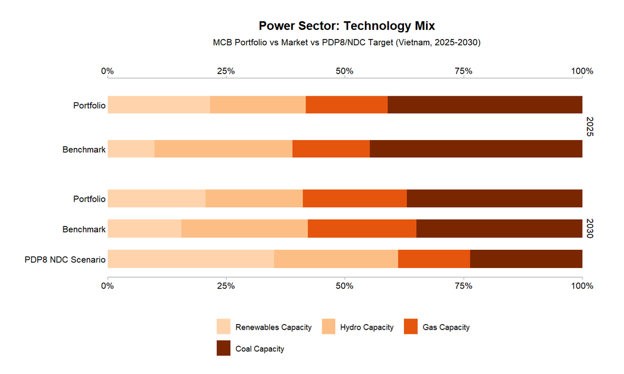

Figure A1: Power sector technology mix — illustrative output from PACTA pipeline (MCB synthetic portfolio).

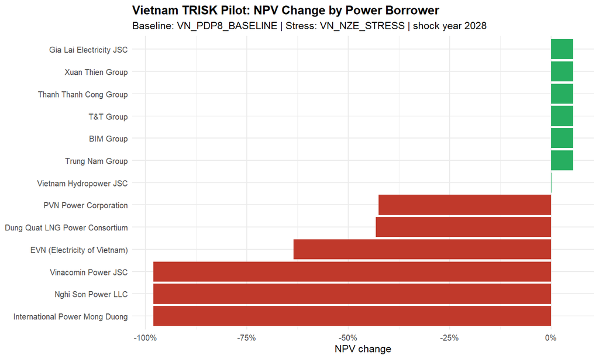

Figure A2: TRISK NPV change by company — illustrative output from power sector stress test (MCB synthetic portfolio).

**Important Disclaimer:** TRISK probability of default (PD) changes are scenario-horizon stress summaries for comparative ranking purposes only. They are **not regulatory PDs** and should not be used as inputs to regulatory capital models. All charts in this appendix are based on synthetic portfolio data (MCB) and illustrative scenario assumptions.

### Source Citations

- PACTA: RMI (Rocky Mountain Institute), r2dii package ecosystem (r2dii.data, r2dii.match, r2dii.analysis, r2dii.plot) — CRAN
- TRISK: Baer et al. (2022), trisk.model R package — CRAN
- Decision 263: Quyết định 263/QĐ-TTg (2022), MONRE implementing regulations
- Scenarios: Vietnam PDP8, Vietnam NDC, IEA NZE 2050

BIDV Framework Recommendation Report — May 23, 2026  
Prepared by GTB Advisory | Illustrative analysis using synthetic MCB portfolio  
CONFIDENTIAL — For authorized recipients only. Not for public distribution.